# Lecture 14 - Parameter estimation

Joshua Loftus

#### Announcements

- Will start posting suggested reading on course page
- Midterms returned tomorrow
- Homework 5 will be posted soon
- Today: parameter estimation, bias

#### Motivating example

Albert Michelson, physicist, conducted experiments to measure the speed of light. Here is a dataset of 100 measurements:

```r
morley$Speed
```

```
##   [1]  850  740  900 1070  930  850  950  980  980  880 1000  980  930  650
##  [15]  760  810 1000 1000  960  960  960  940  960  940  880  800  850  880
##  [29]  900  840  830  790  810  880  880  830  800  790  760  800  880  880
##  [43]  880  860  720  720  620  860  970  950  880  910  850  870  840  840
##  [57]  850  840  840  840  890  810  810  820  800  770  760  740  750  760
##  [71]  910  920  890  860  880  720  840  850  850  780  890  840  780  810
##  [85]  760  810  790  810  820  850  870  870  810  740  810  940  950  800
##  [99]  810  870
```

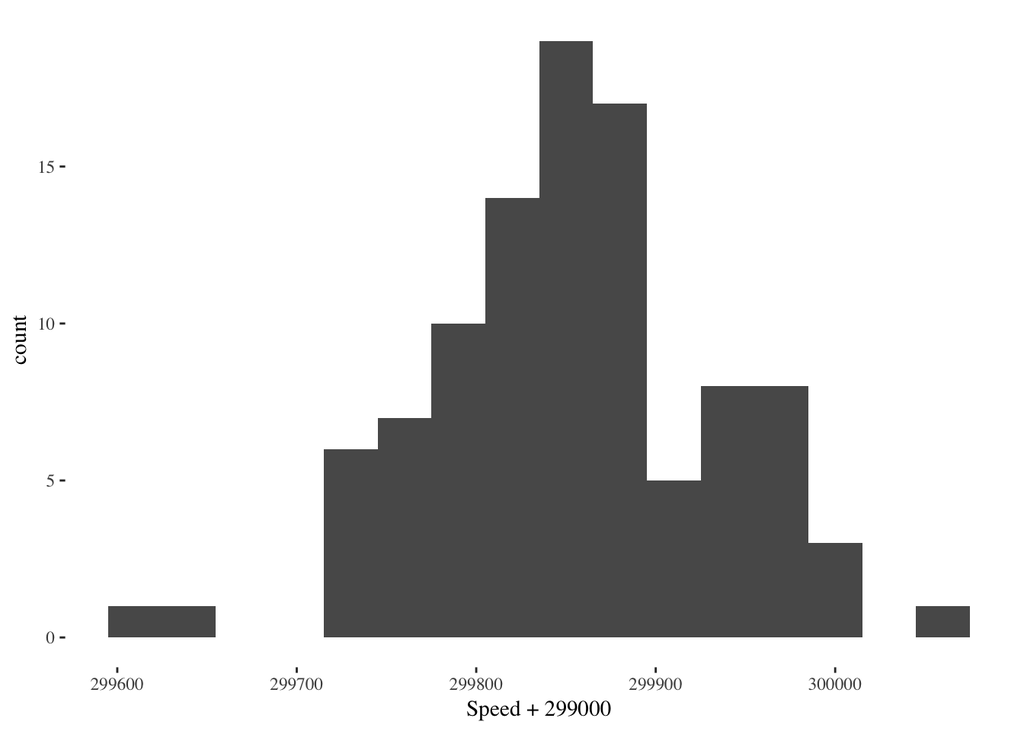

```r
ggplot(morley, aes(Speed + 299000)) + geom_histogram(bins = 16) + theme_tufte()
```

To deal with fewer digits, we look just at the part without the 299,000, i.e. the last 3 digits. These have mean and variance:

```r
Xbar = mean(morley$Speed)
sigma2 = var(morley$Speed)
Xbar
```

```
## [1] 852.4
```

```r
sigma2
```

```
## [1] 6242.667
```

```r
Xbar - 2*sqrt(sigma2/100)
```

```
## [1] 836.5979
```

```r
Xbar + 2*sqrt(sigma2/100)
```

```
## [1] 868.2021
```

- This means that if Michelson redid the same experiments and collected 100 measurements again, his new $\bar X$ will probably be within the range above
- But does it mean the true speed of light is somewhere in that range?…

#### Estimates of parameters

- As we start thinking about parameters in general, rather than specifically the mean ($\mu$), we’ll use $\theta$ to denote the unknown parameter, a representation of the underlying truth
- We can’t measure $\theta$ perfectly, there is some variability or randomness causing us to get different answers each time we take the measurement
- We collect data and use the plug-in principle, constructing an **estimate** $\hat \theta$ from the data
- Is $\hat \theta$ close to the true $\theta$? How close? And how sure can we be about it?
- Last time we considered the specific example of estimating the mean $\mu$
- We take $n$ measurements and use the mean of that sample, $\bar x$, as an **estimate** of $\mu$
- To gain insight about how well this works, we need a mathematical model
- Think of the individual measurements as being samples of a random variable $X$, and the mean of $n$ of these as a random variable denoted $\bar X$
- We assume the individual measurements are independent and identically distributed (iid)
- In that case, $E[\bar X] = E[X]$ and $\text{Var}( \bar X) = \text{Var}(X)/n$
- If we repeated the experiment many times and plotted a histogram of all the estimates, they would be centered at $E[X]$ and their dispersion would be smaller than the dispersion of $X$ – how much smaller depends on the sample size
- In general, if we have an estimator $\hat \theta$ we might wonder what would happen if we repeated the experiment many times and plotted a histogram of the values of $\hat \theta$ we got each time
- We learned about the *sampling distribution of the mean* but what about the sampling distribution of another estimator?
- And if $\theta$ is a different parameter other than the population mean $\mu$, how can we choose a good $\hat \theta$ to estimate it?

#### Uniform example

- The uniform distribution $U[0,\theta]$ from 0 to $\theta$ is a probability distribution where every real number between 0 and $\theta$ has equal probability of being the outcome
- Evenly distributed, flat, not like a bell curve or binomial
- The maximum possible value that it can take on is $\theta$, this is the parameter we want to estimate
- Does it make sense to use the mean of a sample to estimate $\theta$?…
- (No, the mean will be near the center, not near the maximum!)

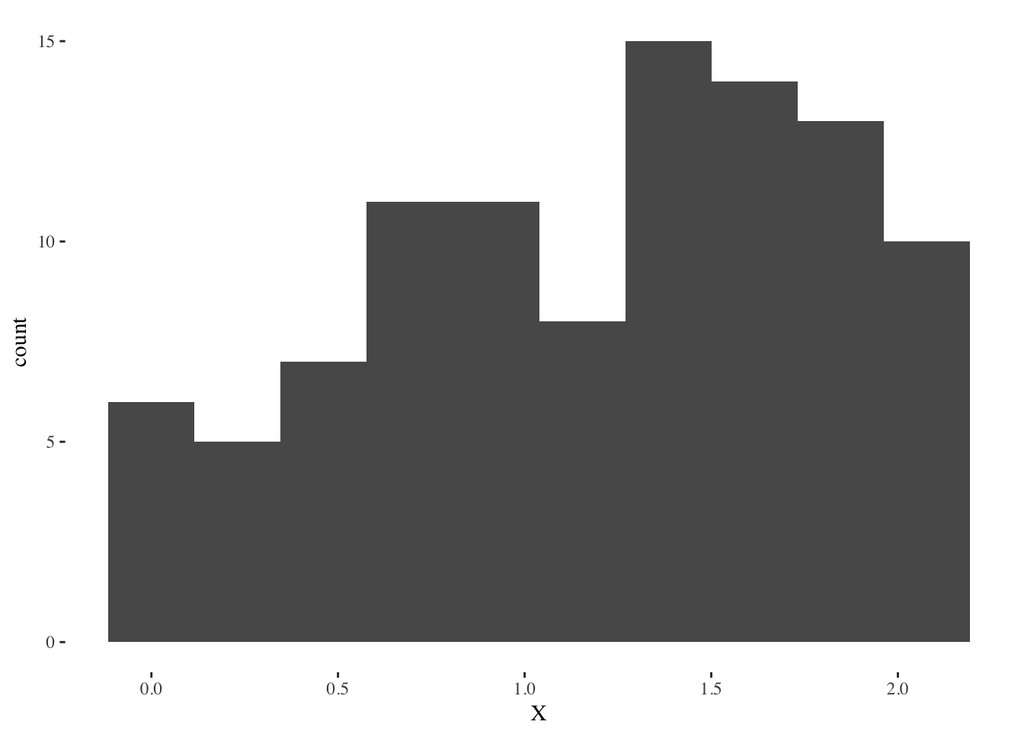

```r
n <- 100
X <- runif(n, min = 0, max = theta)
qplot(X, bins = 10) + theme_tufte()
```

- Use the maximum value of the sample! $x_{(n)} = \text{max} \{ x_1, \ldots, x_n \}$

```r
max(X)
```

```
## [1] 2.102546
```

- Does this work? Well, we need a mathematical model to answer that question
- Sampling distribution of the maximum $X_{(n)} = \text{max} \{ X_1, \ldots, X_n \}$
- Can think of this as a random variable representing the variability that would happen if we took a new sample and found its maximum, and then repeated that many times

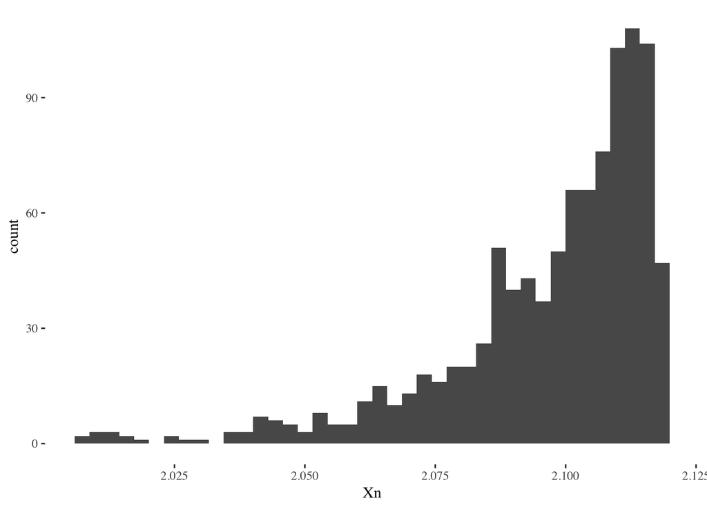

```r
Xn <- replicate(1000, max(runif(n, min = 0, max = theta)))
qplot(Xn, bins = 40) + theme_tufte()
```

- Interesting! This is not shaped like a bell curve at all, is it?
- Is it centered at the true value $\theta$?…

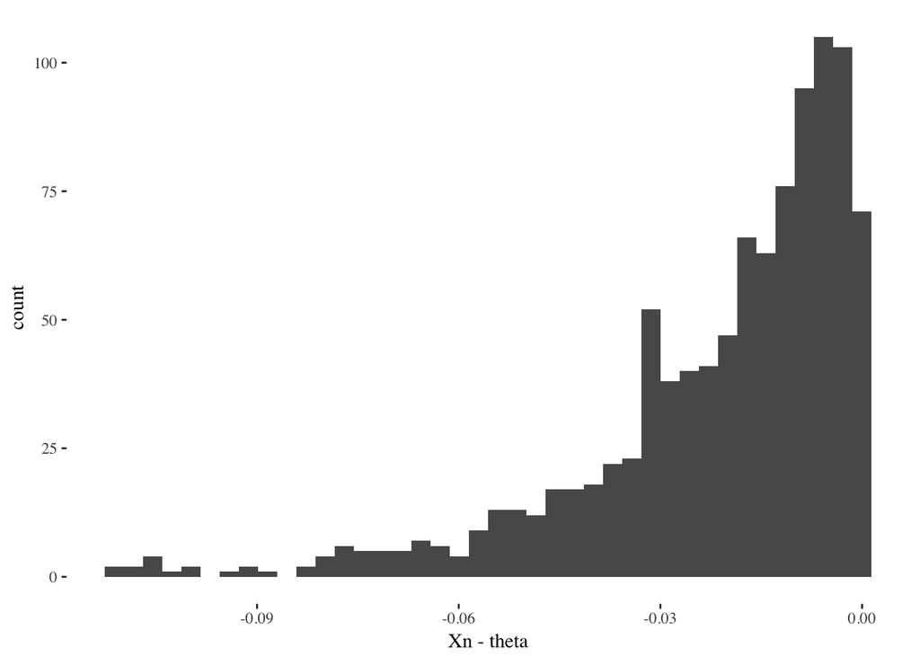

```r
qplot(Xn - theta, bins = 40) + theme_tufte()
```

- Seems like it’s always smaller than $\theta$…

#### Biased/unbiased estimators

- We say that $\hat \theta$ is an **unbiased** estimate of $\theta$ if $E[\hat \theta] = \theta$
- For the $U[0,\theta]$ example, it turns out (need some calculus to show)
  $$E[X_{(n)}] = \frac{n}{n+1} \theta$$
- This is not unbiased. We say it’s a biased estimate.
- But we know how to fix it! Consider $\hat \theta = \frac{n+1}{n} X_{(n)}$

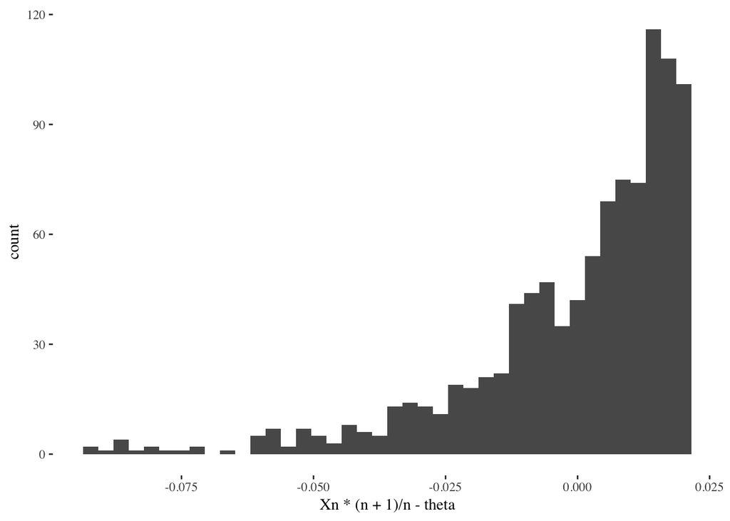

```r
qplot(Xn*(n+1)/n - theta, bins = 40) + theme_tufte()
```

```r
mean(Xn) - theta
```

```
## [1] -0.02117188
```

```r
mean(Xn*(n+1)/n) - theta
```

```
## [1] -0.0002032562
```

- We were able to fix this example, but in general it is not always possible to remove bias
- Bias can be a very serious problem!
- Consider the sample mean example again
- We know $E[\bar X] = E[X]$, and $\text{Var}(\bar X) = \text{Var}(X)/n$
- The fact that the variance decreases in $n$ is what makes gathering more data useful! It means $\bar X$ will be concentrated around $E[X]$…
- But what if $E[X] \neq \mu$?!
- How could this happen? Think of some examples. Usually it means there is a tendency to either overestimate or underestimate.

#### Sample variance / standard deviation

- Suppose that instead of the mean, the parameter we want to estimate is the variance $\theta = \sigma^2$
- Remember the sample standard deviation formula? It has a fraction with $n-1$ instead of $n$ in the denominator. Why is that?
- With some algebra, it can be shown
  $$E\left[\frac{1}{n} \sum_{i=1}^n (X_i - \bar X)^2 \right] = \frac{n-1}{n} \sigma^2$$
- This is $< \sigma^2$, it underestimates the variance

#### Perils of big data

- Around the 2010’s, the “big data” trend was really taking off
- People believe the size of datasets used by modern internet companies is so large that, basically, data = truth
- No need for a model, no need to worry about variability or error, just assume $\bar x = \mu$ because the sample is the whole population
- Not true!
- Always remember this: even if the *variance* of an estimator decreases as the sample size $n$ increases, **bias is a separate issue**
- No sample size is large enough to remove bias, it requires understanding *why* the estimate is not centered at the truth.
- e.g. why does it tend to overestimate, and by how much?